# Project - Ford Go Bike 2019 Data Exploration

## by (Ibrahim Sayed Ahmed)

## Investigation Overview

> The data set includes information about individual rides made in a bike-sharing system covering the greater San Francisco Bay area. This exploration and visualization study primarily focuses on finding the bike usage pattern and customer habit characteristics from the trips data in 2019.

## Dataset Overview

> The dataset used for this exploratory analysis consists of monthly individual trip data in CSV format covering the greater San Francisco Bay area. Visualizations below are created from wrangled and cleaned data to facilitate exploration analysis and help discover usage pattern and rider characteristics.

## User Types and Their Weekly Usage

> Subscribers contributed the majority of rides, about 90%, while about 10% were consumed by cusomters. Subscribers use the service daily and more during weekdays than weekends , Tue, Wed, Thu see the peak usage of this service

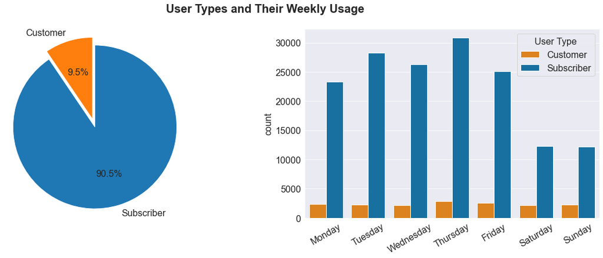

## Average Weekday Trip Duration for Customers and Subscribers

> subscribers take significantly shorter/quicker trips than customers on each day of the week. On Saturdays and Sundays, both user types have a noticeable increase in trip duration over weekends, particularly casual riders. Subscribers seem to be more effective than consumers in general, with a very consistent average period from Monday to Friday.

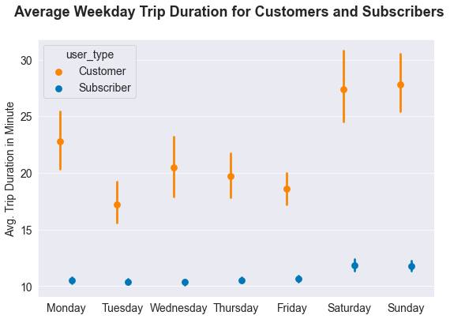

## Hourly Usage for Customers and Subscribers

> Many trips concentrated around 8-9 am and 5-6 pm on work days for subscribers when used for work commute.

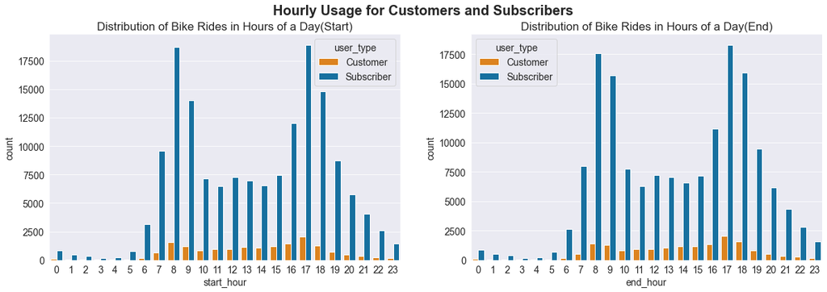